# Teoría de elementos finitos y su implementación (10/12/2018)

## 1. Introducción a MATLAB

MATLAB que derivada de su nombre *laboratorio de matrices*, es un lenguaje de computación desarrollado para el procesamiento de datos en forma de arreglo de números. MATLAB integra computación y visualización y provee diversidad de instrucciones y funciones que pueden ser usados de una manera interactiva para obtener soluciones numéricas para una variedad de problemas de ingeniería.

[Recurso online](https://matlabacademy.mathworks.com/R2018b/es/portal.html?course=gettingstarted) (es necesario tener conexión a internet e identificarse con su cuenta asociada a MATLAB).

[Introduction to MATLAB -- MIT](https://ocw.mit.edu/courses/electrical-engineering-and-computer-science/6-094-introduction-to-matlab-january-iap-2010/)

[MATLAB Primer](https://www.mathworks.com/help/pdf_doc/matlab/getstart.pdf)

[Documentación oficial en PDF](https://www.mathworks.com/help/pdf_doc/matlab/index.html)

[Math Modeling Computing and Communication (SIAM)](https://m3challenge.siam.org/sites/default/files/uploads/siam-technical-guidebook-web.pdf)

## Cómo leer los cuadernos

Estos cuadernos están conformados por celdas, algunas de ellas están en formato [**Markdown**](https://daringfireball.net/projects/markdown/) y otras como para ejecutar en el prompt de MATLAB. (Estas últimas las puede identificar porque al lado izquierdo aparece `In [x]` donde $x\in\mathbb{N}$.)

> **Nota:** MATLAB distingue entre mayúsculas y minúsculas, lo que significa que `a + B` no es lo mismo que `a + b`.

### 1.1. Expresiones numéricas

```matlab
7
7.1
7.92
42.13; % No hay réplica.
```

```
ans =

     7


ans =

    7.1000


ans =

    7.9200
```

#### 1.1.1. Operaciones aritméticas con escalares

$(+,-,\ast,/,\hat{})$ adición, sustracción, multiplicación, división y exponenciación. Así por ejemplo.

```matlab
2/3 + 4*5 - 3^2
```

```
ans =

   11.6667
```

> Nota: `clc` y `clear` son comandos para limpiar la consola y borrar las variables, respectivamente.

#### 1.1.2. Asignación de valores numéricos a nombres de variables

```matlab
x = 5;
y = 2 + 2*x
z = (x + y)^2
```

```
y =

    12


z =

   289
```

#### 1.1.3. Números complejos

```matlab
z = 2 - 3*i % Otra expresión válida es z = 2+5j
```

```
z =

   2.0000 - 3.0000i
```

#### 1.1.4. Funciones matemáticas

Hay una lista grande de funciones matemáticas que son reservadas por MATLAB. Listemos algunas de ellas

[output not shown]

```matlab
clear all
x = 4;
z = sin(x) - log(cos(x))
```

```
z =

  -0.3316 - 3.1416i
```

#### 1.1.5. Formatos de salida

- `format short`.
- `format long`.

```matlab
format short
fprintf('El valor de pi es:'); disp(pi);
fprintf('El valor de cos(1.57) es:'); disp(cos(1.57));
format long
fprintf('El valor de pi es:'); disp(pi);
fprintf('El valor de cos(1.57) es:'); disp(cos(1.57));
```

```
El valor de pi es:    3.1416

El valor de cos(1.57) es:   7.9633e-04

El valor de pi es:   3.141592653589793

El valor de cos(1.57) es:     7.963267107332633e-04
```

#### 1.1.6. Vectores

Creación de vectores fila.

```matlab
u = [2 3 4 5] % Sin separación de comas.
```

```
u =

     2     3     4     5
```

o equivalentemente

```matlab
u = [2, 3, 4, 5]; % Con separación de comas.
x = 2:5;
y = 2:0.1:3
z = 5:-1:1
p = [1, 7 + 3i, 4, 3 - 5i]
```

```
y =

  Columns 1 through 3

   2.000000000000000   2.100000000000000   2.200000000000000

  Columns 4 through 6

   2.300000000000000   2.400000000000000   2.500000000000000

  Columns 7 through 9

   2.600000000000000   2.700000000000000   2.800000000000000

  Columns 10 through 11

   2.900000000000000   3.000000000000000


z =

     5     4     3     2     1


p =

  Column 1

  1.000000000000000 + 0.000000000000000i

  Column 2

  7.000000000000000 + 3.000000000000000i

  Column 3

  4.000000000000000 + 0.000000000000000i

  Column 4

  3.000000000000000 - 5.000000000000000i
```

Creación de vectores columna

```matlab
w = u'
m = p'
q = conj(p')
```

```
w =

     2
     3
     4
     5


m =

  1.000000000000000 + 0.000000000000000i
  7.000000000000000 - 3.000000000000000i
  4.000000000000000 + 0.000000000000000i
  3.000000000000000 + 5.000000000000000i


q =

  1.000000000000000 + 0.000000000000000i
  7.000000000000000 + 3.000000000000000i
  4.000000000000000 + 0.000000000000000i
  3.000000000000000 - 5.000000000000000i
```

#### 1.1.7. Matrices

Crear una matriz de $3\times4$.

```matlab
A = [2 3 5 6; .2 4 5 1; 0 1 5 2]
[m, n] = size(A) % Orden de la matriz A.
```

```
A =

  Columns 1 through 3

   2.000000000000000   3.000000000000000   5.000000000000000
   0.200000000000000   4.000000000000000   5.000000000000000
                   0   1.000000000000000   5.000000000000000

  Column 4

   6.000000000000000
   1.000000000000000
   2.000000000000000


m =

     3


n =

     4
```

#### 1.1.8. Generación de matrices especiales

```matlab
X = ones(n, n) % Matriz de unos.
Z = zeros(m, n) % Matriz de ceros.
d = eye(n, n) % Matriz identidad.
```

```
X =

     1     1     1     1
     1     1     1     1
     1     1     1     1
     1     1     1     1


Z =

     0     0     0     0
     0     0     0     0
     0     0     0     0


d =

     1     0     0     0
     0     1     0     0
     0     0     1     0
     0     0     0     1
```

#### 1.1.9. Operaciones con matrices $A+B$, $A-B$, $A\ast B$

```matlab
B = magic(4)
```

```
B =

    16     2     3    13
     5    11    10     8
     9     7     6    12
     4    14    15     1
```

```matlab
help("magic") % Descripción corta del comando magic.
```

```
 MAGIC  Magic square.
    MAGIC(N) is an N-by-N matrix constructed from the integers
    1 through N^2 with equal row, column, and diagonal sums.
    Produces valid magic squares for all N > 0 except N = 2.

    Reference page in Doc Center
       doc magic
```

Manipulación con elementos de una matriz

```matlab
B(2, :) = 5 * B(2, :)
% Nueva matriz B. Multiplicación por 5 a la fila 2 de la matriz B.
B_1 = B(:, 3)
% Obtención de la tercera columna de B.
C = B(:, 2) + B(:, 4)
% Suma de las columnas 2 y 4 de la nueva matriz B.
```

```
B =

    16     2     3    13
    25    55    50    40
     9     7     6    12
     4    14    15     1


B_1 =

     3
    50
     6
    15


C =

    15
    95
    19
    15
```

#### 1.1.10. $P$-norma de una matriz

Por ejemplo:

```
m
norm(x, p)
norm(x, Inf)
```

```matlab
help norm
```

```
 NORM   Matrix or vector norm.
      NORM(X,2) returns the 2-norm of X.

      NORM(X) is the same as NORM(X,2).

      NORM(X,1) returns the 1-norm of X.

      NORM(X,Inf) returns the infinity norm of X.

      NORM(X,'fro') returns the Frobenius norm of X.

    In addition, for vectors...

      NORM(V,P) returns the p-norm of V defined as SUM(ABS(V).^P)^(1/P).

      NORM(V,Inf) returns the largest element of ABS(V).

      NORM(V,-Inf) returns the smallest element of ABS(V).

    By convention, NaN is returned if X or V contains NaNs.

    See also COND, RCOND, CONDEST, NORMEST, HYPOT.

    Reference page in Doc Center
       doc norm

    Other functions named norm

       codistributed/norm    DynamicSystem/norm    mfilt/norm    tall/norm
       dfilt/norm            gpuArray/norm         sym/norm
```

#### 1.1.11. Determinante e inversa de una matriz

```
m
det(A)
inv(A)
A\B
A/B
```

> $A\backslash B$ significa $A^{-1}B$.

> $A/B$ significa $AB^{-1}$.

#### 1.1.12. Operación dot $\left(\cdot\right)$

Sean las $X$ y $M$ dos matrices del mismo orden. Las siguientes instrucciones realizan operaciones elemento a elemento.

```
m
Zm = X .* M
Zd = X ./ M
Ze = X .^ M
```

Además, si `x0` y `m0` son números reales se tiene los siguientes casos particulares:

```
m
Zd = x0 ./ M
Ze = x0 .^ M
Ze = M .^ m0
```

### 1.2 Ploteando en MATLAB con el comando `plot`

1. Usando el comando `plot(x,y,'o')`, `plot(x,y,'ro-')` plotear

   a. los puntos: $(2,3), (4,5), (9,5)$.

   b. la poligonal que une los puntos $(2,3), (4,5), (9,5)$.
2. Graficar la función $f(x)=x^3+2x-1$ en el intervalo $-2\le x\le 2$.

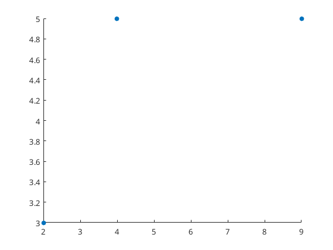

```matlab
% Pregunta 1
% Parte a
scatter([2 4 9], [3 5 5], 'filled');
```

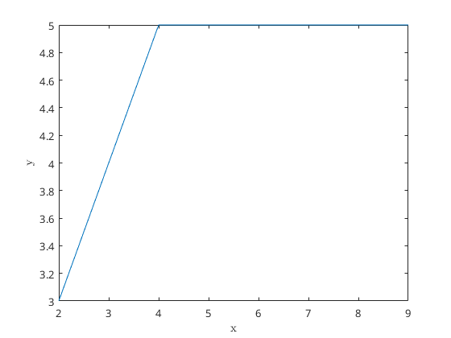

```matlab
% Parte b
syms x y
plot( [2 4 9], [3 5 5] );
xlabel('x','Interpreter','latex');
ylabel('y','Interpreter','latex');
```

```matlab
doc fplot
```

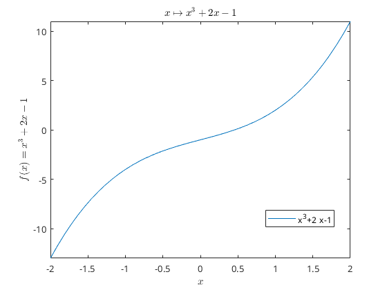

```matlab
% Pregunta 2
syms x y
fplot( @(x) x.^3 + 2.*x - 1, [-2 2] )
xlabel('$x$','Interpreter','latex');
ylabel('$f(x)=x^3+2x-1$','Interpreter','latex');
legend('show','Location','best');
title('$x\mapsto x^3+2x-1$','Interpreter','latex');
```

1. Muestre las gráficas de las funciones en un mismo plano las gráficas de las funciones $$ f(x)=x^3+2x-1,\qquad g(x)=x^2+1$$ en el intervalo $-2\le x\le 2$.

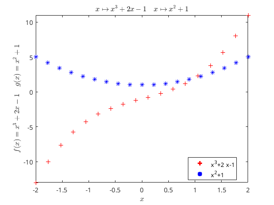

```matlab
% Pregunta 3
I = [-2 2]; % Intervalo
fplot( @(x) x.^3 + 2.*x - 1, I, 'r+', 'LineWidth', 2);
hold on
fplot( @(x) x.^2 + 1, I, 'b*', 'LineWidth', 2)
xlabel('$x$','Interpreter','latex');
ylabel('$f(x)=x^3+2x-1\quad g(x)=x^2+1$','Interpreter','latex');
legend('show','Location','best');
title('$x\mapsto x^3+2x-1\quad x\mapsto x^2+1$','Interpreter','latex');
hold off
```

### 1.3 $M$-file

1. script `M-file`

1. function `M-file`

Crear una función `M-file` para la función $f(x) = x^2 - 1$. Luego, ejecute:

```
a. f(3).
b. f(x), cuando x = 1:5.
```

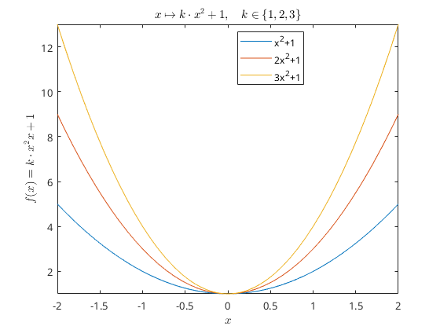

```matlab
% Programa script.m
% Parte a
for k = 1:3
    fplot( @(x) k * x.^2 + 1, [-2 2] )
    hold on
end
xlabel('$x$','Interpreter','latex');
ylabel('$f(x)=k\cdot x^2x+1$','Interpreter','latex');
legend('x^2+1','2x^2+1','3x^2+1','Location','best');
title('$x\mapsto k\cdot x^2+1,\quad k\in\{1,2,3\}$','Interpreter','latex');
hold off
```

```matlab
%%file evalfun.m
function y = evalfun(x)
% evalfun calcula el valor $x\mapsto x^2 -1$
% https://www.mathworks.com/matlabcentral/answers/25568-defining-functions
    if ~isnumeric(x)
        error('Debe ingresar un número real.')
    end
y = x^2 - 1;
end
```

```
Created file '/home/carlosal1015/GitHub/Finite-element-method-FEM/2018/Notebooks/evalfun.m'.
```

```matlab
% Parte a
fprintf('El valor de f(3) es %2.0f.', evalfun(3))
```

```
El valor de f(3) es  8.
```

```matlab
% Parte b
for z = 1:5
    fprintf('El valor de f(%i)=%2.0f.\n', z, evalfun(z))
end
```

```
El valor de f(1)= 0.
El valor de f(2)= 3.
El valor de f(3)= 8.
El valor de f(4)=15.
El valor de f(5)=24.
```